# Risk Factor Analysis

## Outcome Variable

**Outcome Variable:** ever_stunted

## Predictor Variables

**Intervention Variable:** nchldlt5

**Adjustment Set:**

unadjusted

## Stratifying Variables

The analysis was stratified on these variable(s):

- agecat
- studyid

The following strata were considered:

- agecat: 12 months, studyid: ki1000108-IRC
- agecat: 12 months, studyid: ki1017093b-PROVIDE
- agecat: 12 months, studyid: ki1017093c-NIH-Crypto
- agecat: 12 months, studyid: ki1066203-TanzaniaChild2
- agecat: 12 months, studyid: ki1148112-LCNI-5
- agecat: 18 months, studyid: ki1000108-IRC
- agecat: 18 months, studyid: ki1017093b-PROVIDE
- agecat: 18 months, studyid: ki1017093c-NIH-Crypto
- agecat: 18 months, studyid: ki1066203-TanzaniaChild2
- agecat: 18 months, studyid: ki1148112-LCNI-5
- agecat: 24 months, studyid: ki1000108-IRC
- agecat: 24 months, studyid: ki1017093b-PROVIDE
- agecat: 24 months, studyid: ki1017093c-NIH-Crypto
- agecat: 24 months, studyid: ki1066203-TanzaniaChild2
- agecat: 24 months, studyid: ki1148112-LCNI-5
- agecat: 3 months, studyid: ki1000108-IRC
- agecat: 3 months, studyid: ki1017093b-PROVIDE
- agecat: 3 months, studyid: ki1017093c-NIH-Crypto
- agecat: 3 months, studyid: ki1066203-TanzaniaChild2
- agecat: 6 months, studyid: ki1000108-IRC
- agecat: 6 months, studyid: ki1017093b-PROVIDE
- agecat: 6 months, studyid: ki1017093c-NIH-Crypto
- agecat: 6 months, studyid: ki1066203-TanzaniaChild2
- agecat: 6 months, studyid: ki1148112-LCNI-5

### Dropped Strata

Some strata were dropped due to rare outcomes:

- agecat: 3 months, studyid: ki1017093b-PROVIDE
- agecat: 3 months, studyid: ki1017093c-NIH-Crypto
- agecat: 3 months, studyid: ki1066203-TanzaniaChild2
- agecat: 6 months, studyid: ki1017093b-PROVIDE
- agecat: 6 months, studyid: ki1017093c-NIH-Crypto
- agecat: 6 months, studyid: ki1066203-TanzaniaChild2
- agecat: 6 months, studyid: ki1148112-LCNI-5
- agecat: 12 months, studyid: ki1017093b-PROVIDE
- agecat: 12 months, studyid: ki1017093c-NIH-Crypto
- agecat: 12 months, studyid: ki1148112-LCNI-5
- agecat: 18 months, studyid: ki1017093b-PROVIDE
- agecat: 18 months, studyid: ki1017093c-NIH-Crypto
- agecat: 18 months, studyid: ki1148112-LCNI-5
- agecat: 24 months, studyid: ki1017093b-PROVIDE
- agecat: 24 months, studyid: ki1017093c-NIH-Crypto
- agecat: 24 months, studyid: ki1066203-TanzaniaChild2
- agecat: 24 months, studyid: ki1148112-LCNI-5

## Methods Detail

We’re interested in the causal parameters $E[Y_a]$ for all values of $a \in \mathcal{A}$. These parameters represent the mean outcome if, possibly contrary to fact, we intervened to set all units to have $A=a$. Under the randomization and positivity assumptions, these are identified by the statistical parameters $\psi_a=E_W[E_{Y|A,W}(Y|A=a,W)]$. In addition, we’re interested in the mean of $Y$, $E[Y]$ under no intervention (the observed mean). We will estimate these parameters by using SuperLearner to fit the relevant likelihood factors – $E_{Y|A,W}(Y|A=a,W)$ and $p(A=a|W)$, and then updating our likelihood fit using a joint TMLE.

For unadjusted analyses ($W=\{\}$), initial likelihoods were estimated using Lrnr_glm to estimate the simple $E(Y|A)$ and Lrnr_mean to estimate $p(A)$. For adjusted analyses, a small library containing Lrnr_glmnet, Lrnr_xgboost, and Lrnr_mean was used.

Having estimated these parameters, we will then use the delta method to estimate relative risks and attributable risks relative to a prespecified baseline level of $A$.

# Results Detail

## Results Plots

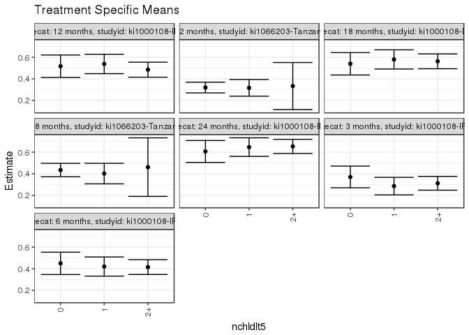

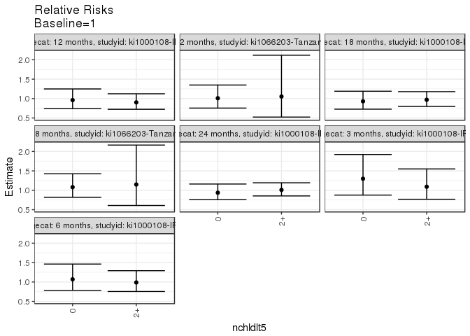

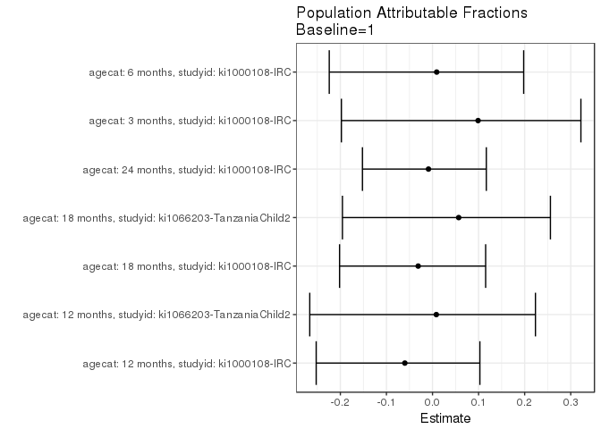

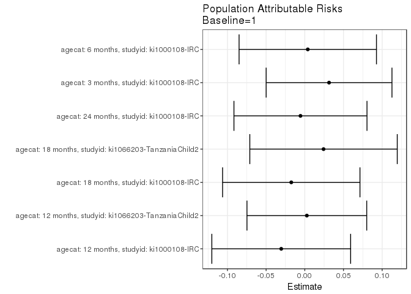

## Data Summary

| agecat | studyid | A | n | nA | nAY0 | nAY1 |
| --- | --- | --- | --- | --- | --- | --- |
| 3 months | ki1000108-IRC | 1 | 410 | 119 | 85 | 34 |
| 3 months | ki1000108-IRC | 0 | 410 | 89 | 56 | 33 |
| 3 months | ki1000108-IRC | 2+ | 410 | 202 | 139 | 63 |
| 3 months | ki1017093b-PROVIDE | 1 | 175 | 47 | 37 | 10 |
| 3 months | ki1017093b-PROVIDE | 0 | 175 | 125 | 91 | 34 |
| 3 months | ki1017093b-PROVIDE | 2+ | 175 | 3 | 3 | 0 |
| 3 months | ki1017093c-NIH-Crypto | 1 | 758 | 211 | 176 | 35 |
| 3 months | ki1017093c-NIH-Crypto | 0 | 758 | 541 | 455 | 86 |
| 3 months | ki1017093c-NIH-Crypto | 2+ | 758 | 6 | 6 | 0 |
| 3 months | ki1066203-TanzaniaChild2 | 1 | 600 | 163 | 150 | 13 |
| 3 months | ki1066203-TanzaniaChild2 | 0 | 600 | 414 | 369 | 45 |
| 3 months | ki1066203-TanzaniaChild2 | 2+ | 600 | 23 | 22 | 1 |
| 3 months | ki1148112-LCNI-5 | 1 | 0 | 0 | 0 | 0 |
| 3 months | ki1148112-LCNI-5 | 0 | 0 | 0 | 0 | 0 |
| 3 months | ki1148112-LCNI-5 | 2+ | 0 | 0 | 0 | 0 |
| 6 months | ki1000108-IRC | 1 | 408 | 119 | 69 | 50 |
| 6 months | ki1000108-IRC | 0 | 408 | 89 | 49 | 40 |
| 6 months | ki1000108-IRC | 2+ | 408 | 200 | 117 | 83 |
| 6 months | ki1017093b-PROVIDE | 1 | 166 | 45 | 33 | 12 |
| 6 months | ki1017093b-PROVIDE | 0 | 166 | 118 | 82 | 36 |
| 6 months | ki1017093b-PROVIDE | 2+ | 166 | 3 | 3 | 0 |
| 6 months | ki1017093c-NIH-Crypto | 1 | 736 | 207 | 133 | 74 |
| 6 months | ki1017093c-NIH-Crypto | 0 | 736 | 523 | 371 | 152 |
| 6 months | ki1017093c-NIH-Crypto | 2+ | 736 | 6 | 6 | 0 |
| 6 months | ki1066203-TanzaniaChild2 | 1 | 556 | 154 | 128 | 26 |
| 6 months | ki1066203-TanzaniaChild2 | 0 | 556 | 383 | 305 | 78 |
| 6 months | ki1066203-TanzaniaChild2 | 2+ | 556 | 19 | 15 | 4 |
| 6 months | ki1148112-LCNI-5 | 1 | 132 | 63 | 43 | 20 |
| 6 months | ki1148112-LCNI-5 | 0 | 132 | 1 | 1 | 0 |
| 6 months | ki1148112-LCNI-5 | 2+ | 132 | 68 | 37 | 31 |
| 12 months | ki1000108-IRC | 1 | 408 | 119 | 55 | 64 |
| 12 months | ki1000108-IRC | 0 | 408 | 89 | 43 | 46 |
| 12 months | ki1000108-IRC | 2+ | 408 | 200 | 103 | 97 |
| 12 months | ki1017093b-PROVIDE | 1 | 159 | 45 | 28 | 17 |
| 12 months | ki1017093b-PROVIDE | 0 | 159 | 111 | 73 | 38 |
| 12 months | ki1017093b-PROVIDE | 2+ | 159 | 3 | 2 | 1 |
| 12 months | ki1017093c-NIH-Crypto | 1 | 729 | 205 | 115 | 90 |
| 12 months | ki1017093c-NIH-Crypto | 0 | 729 | 519 | 332 | 187 |
| 12 months | ki1017093c-NIH-Crypto | 2+ | 729 | 5 | 5 | 0 |
| 12 months | ki1066203-TanzaniaChild2 | 1 | 495 | 139 | 95 | 44 |
| 12 months | ki1066203-TanzaniaChild2 | 0 | 495 | 338 | 230 | 108 |
| 12 months | ki1066203-TanzaniaChild2 | 2+ | 495 | 18 | 12 | 6 |
| 12 months | ki1148112-LCNI-5 | 1 | 392 | 182 | 99 | 83 |
| 12 months | ki1148112-LCNI-5 | 0 | 392 | 3 | 0 | 3 |
| 12 months | ki1148112-LCNI-5 | 2+ | 392 | 207 | 104 | 103 |
| 18 months | ki1000108-IRC | 1 | 409 | 119 | 50 | 69 |
| 18 months | ki1000108-IRC | 0 | 409 | 89 | 41 | 48 |
| 18 months | ki1000108-IRC | 2+ | 409 | 201 | 88 | 113 |
| 18 months | ki1017093b-PROVIDE | 1 | 155 | 44 | 24 | 20 |
| 18 months | ki1017093b-PROVIDE | 0 | 155 | 109 | 59 | 50 |
| 18 months | ki1017093b-PROVIDE | 2+ | 155 | 2 | 2 | 0 |
| 18 months | ki1017093c-NIH-Crypto | 1 | 715 | 202 | 98 | 104 |
| 18 months | ki1017093c-NIH-Crypto | 0 | 715 | 508 | 296 | 212 |
| 18 months | ki1017093c-NIH-Crypto | 2+ | 715 | 5 | 4 | 1 |
| 18 months | ki1066203-TanzaniaChild2 | 1 | 359 | 102 | 61 | 41 |
| 18 months | ki1066203-TanzaniaChild2 | 0 | 359 | 244 | 138 | 106 |
| 18 months | ki1066203-TanzaniaChild2 | 2+ | 359 | 13 | 7 | 6 |
| 18 months | ki1148112-LCNI-5 | 1 | 325 | 153 | 75 | 78 |
| 18 months | ki1148112-LCNI-5 | 0 | 325 | 2 | 0 | 2 |
| 18 months | ki1148112-LCNI-5 | 2+ | 325 | 170 | 65 | 105 |
| 24 months | ki1000108-IRC | 1 | 410 | 119 | 42 | 77 |
| 24 months | ki1000108-IRC | 0 | 410 | 89 | 35 | 54 |
| 24 months | ki1000108-IRC | 2+ | 410 | 202 | 70 | 132 |
| 24 months | ki1017093b-PROVIDE | 1 | 148 | 42 | 20 | 22 |
| 24 months | ki1017093b-PROVIDE | 0 | 148 | 104 | 54 | 50 |
| 24 months | ki1017093b-PROVIDE | 2+ | 148 | 2 | 2 | 0 |
| 24 months | ki1017093c-NIH-Crypto | 1 | 634 | 182 | 77 | 105 |
| 24 months | ki1017093c-NIH-Crypto | 0 | 634 | 448 | 237 | 211 |
| 24 months | ki1017093c-NIH-Crypto | 2+ | 634 | 4 | 2 | 2 |
| 24 months | ki1066203-TanzaniaChild2 | 1 | 250 | 70 | 35 | 35 |
| 24 months | ki1066203-TanzaniaChild2 | 0 | 250 | 172 | 93 | 79 |
| 24 months | ki1066203-TanzaniaChild2 | 2+ | 250 | 8 | 3 | 5 |
| 24 months | ki1148112-LCNI-5 | 1 | 351 | 165 | 64 | 101 |
| 24 months | ki1148112-LCNI-5 | 0 | 351 | 3 | 0 | 3 |
| 24 months | ki1148112-LCNI-5 | 2+ | 351 | 183 | 57 | 126 |

## Results Table

### Parameter: TSM

| agecat | studyid | intervention_level | baseline_level | estimate | ci_lower | ci_upper |
| --- | --- | --- | --- | --- | --- | --- |
| 3 months | ki1000108-IRC | 1 | NA | 0.2857143 | 0.2044487 | 0.3669799 |
| 3 months | ki1000108-IRC | 0 | NA | 0.3707865 | 0.2703147 | 0.4712584 |
| 3 months | ki1000108-IRC | 2+ | NA | 0.3118812 | 0.2479182 | 0.3758442 |
| 6 months | ki1000108-IRC | 1 | NA | 0.4201681 | 0.3313768 | 0.5089593 |
| 6 months | ki1000108-IRC | 0 | NA | 0.4494382 | 0.3459659 | 0.5529105 |
| 6 months | ki1000108-IRC | 2+ | NA | 0.4150000 | 0.3466296 | 0.4833704 |
| 12 months | ki1000108-IRC | 1 | NA | 0.5378151 | 0.4481276 | 0.6275026 |
| 12 months | ki1000108-IRC | 0 | NA | 0.5168539 | 0.4129076 | 0.6208002 |
| 12 months | ki1000108-IRC | 2+ | NA | 0.4850000 | 0.4156510 | 0.5543490 |
| 12 months | ki1066203-TanzaniaChild2 | 1 | NA | 0.3165468 | 0.2391446 | 0.3939489 |
| 12 months | ki1066203-TanzaniaChild2 | 0 | NA | 0.3195266 | 0.2697658 | 0.3692875 |
| 12 months | ki1066203-TanzaniaChild2 | 2+ | NA | 0.3333333 | 0.1153392 | 0.5513274 |
| 18 months | ki1000108-IRC | 1 | NA | 0.5798319 | 0.4910410 | 0.6686229 |
| 18 months | ki1000108-IRC | 0 | NA | 0.5393258 | 0.4356429 | 0.6430088 |
| 18 months | ki1000108-IRC | 2+ | NA | 0.5621891 | 0.4935192 | 0.6308589 |
| 18 months | ki1066203-TanzaniaChild2 | 1 | NA | 0.4019608 | 0.3066789 | 0.4972427 |
| 18 months | ki1066203-TanzaniaChild2 | 0 | NA | 0.4344262 | 0.3721444 | 0.4967081 |
| 18 months | ki1066203-TanzaniaChild2 | 2+ | NA | 0.4615385 | 0.1901675 | 0.7329095 |
| 24 months | ki1000108-IRC | 1 | NA | 0.6470588 | 0.5610926 | 0.7330251 |
| 24 months | ki1000108-IRC | 0 | NA | 0.6067416 | 0.5051344 | 0.7083487 |
| 24 months | ki1000108-IRC | 2+ | NA | 0.6534653 | 0.5877620 | 0.7191687 |

### Parameter: E(Y)

| agecat | studyid | intervention_level | baseline_level | estimate | ci_lower | ci_upper |
| --- | --- | --- | --- | --- | --- | --- |
| 3 months | ki1000108-IRC | NA | NA | 0.3170732 | 0.3141257 | 0.3200207 |
| 6 months | ki1000108-IRC | NA | NA | 0.4240196 | 0.4226977 | 0.4253415 |
| 12 months | ki1000108-IRC | NA | NA | 0.5073529 | 0.5051052 | 0.5096006 |
| 12 months | ki1066203-TanzaniaChild2 | NA | NA | 0.3191919 | 0.3189228 | 0.3194610 |
| 18 months | ki1000108-IRC | NA | NA | 0.5623472 | 0.5609603 | 0.5637341 |
| 18 months | ki1066203-TanzaniaChild2 | NA | NA | 0.4261838 | 0.4245195 | 0.4278482 |
| 24 months | ki1000108-IRC | NA | NA | 0.6414634 | 0.6396718 | 0.6432550 |

### Parameter: RR

| agecat | studyid | intervention_level | baseline_level | estimate | ci_lower | ci_upper |
| --- | --- | --- | --- | --- | --- | --- |
| 3 months | ki1000108-IRC | 0 | 1 | 1.2977528 | 0.8761590 | 1.922211 |
| 3 months | ki1000108-IRC | 2+ | 1 | 1.0915842 | 0.7687201 | 1.550052 |
| 6 months | ki1000108-IRC | 0 | 1 | 1.0696629 | 0.7825757 | 1.462068 |
| 6 months | ki1000108-IRC | 2+ | 1 | 0.9877000 | 0.7555342 | 1.291207 |
| 12 months | ki1000108-IRC | 0 | 1 | 0.9610253 | 0.7400675 | 1.247953 |
| 12 months | ki1000108-IRC | 2+ | 1 | 0.9017969 | 0.7239472 | 1.123338 |
| 12 months | ki1066203-TanzaniaChild2 | 0 | 1 | 1.0094137 | 0.7553816 | 1.348876 |
| 12 months | ki1066203-TanzaniaChild2 | 2+ | 1 | 1.0530303 | 0.5238615 | 2.116729 |
| 18 months | ki1000108-IRC | 0 | 1 | 0.9301417 | 0.7274585 | 1.189296 |
| 18 months | ki1000108-IRC | 2+ | 1 | 0.9695724 | 0.7970951 | 1.179371 |
| 18 months | ki1066203-TanzaniaChild2 | 0 | 1 | 1.0807677 | 0.8192601 | 1.425749 |
| 18 months | ki1066203-TanzaniaChild2 | 2+ | 1 | 1.1482176 | 0.6091177 | 2.164448 |
| 24 months | ki1000108-IRC | 0 | 1 | 0.9376915 | 0.7572225 | 1.161172 |
| 24 months | ki1000108-IRC | 2+ | 1 | 1.0099010 | 0.8549072 | 1.192995 |

### Parameter: PAR

| agecat | studyid | intervention_level | baseline_level | estimate | ci_lower | ci_upper |
| --- | --- | --- | --- | --- | --- | --- |
| 3 months | ki1000108-IRC | 1 | NA | 0.0313589 | -0.0499602 | 0.1126779 |
| 6 months | ki1000108-IRC | 1 | NA | 0.0038515 | -0.0849495 | 0.0926526 |
| 12 months | ki1000108-IRC | 1 | NA | -0.0304622 | -0.1201778 | 0.0592535 |
| 12 months | ki1066203-TanzaniaChild2 | 1 | NA | 0.0026452 | -0.0747575 | 0.0800478 |
| 18 months | ki1000108-IRC | 1 | NA | -0.0174847 | -0.1062865 | 0.0713170 |
| 18 months | ki1066203-TanzaniaChild2 | 1 | NA | 0.0242231 | -0.0710734 | 0.1195195 |
| 24 months | ki1000108-IRC | 1 | NA | -0.0055954 | -0.0915803 | 0.0803895 |

### Parameter: PAF

| agecat | studyid | intervention_level | baseline_level | estimate | ci_lower | ci_upper |
| --- | --- | --- | --- | --- | --- | --- |
| 3 months | ki1000108-IRC | 1 | NA | 0.0989011 | -0.1977458 | 0.3220772 |
| 6 months | ki1000108-IRC | 1 | NA | 0.0090834 | -0.2241188 | 0.1978591 |
| 12 months | ki1000108-IRC | 1 | NA | -0.0600414 | -0.2524849 | 0.1028333 |
| 12 months | ki1066203-TanzaniaChild2 | 1 | NA | 0.0082870 | -0.2664281 | 0.2234106 |
| 18 months | ki1000108-IRC | 1 | NA | -0.0310924 | -0.2017405 | 0.1153235 |
| 18 months | ki1066203-TanzaniaChild2 | 1 | NA | 0.0568371 | -0.1954930 | 0.2559085 |
| 24 months | ki1000108-IRC | 1 | NA | -0.0087229 | -0.1520827 | 0.1167979 |